# Hw09 - Universal Kriging/Autoregressive Homework

Author

Brady Lamson

Published

December 2, 2025

# Problem 1 (Autoregressive modeling)

The file `penn_spdf.rda` contains an `sf` `data.frame` related to lung cancer deaths for 67 Pennsylvania counties in 2002. The data are simplified from the `pennLC` data available in the **SpatialEpi** package. The data frame includes the variables:

- `cases`: the number of lung cancer cases in the county
- `pop`: the county population of the counties
- `rate`: the lung cancer rate (`cases`/`pop`)
- `smoking`: the proportion of the population that smokes.

## (a)

Create a choropleth map of lung cancer `rate`.

**Solution**

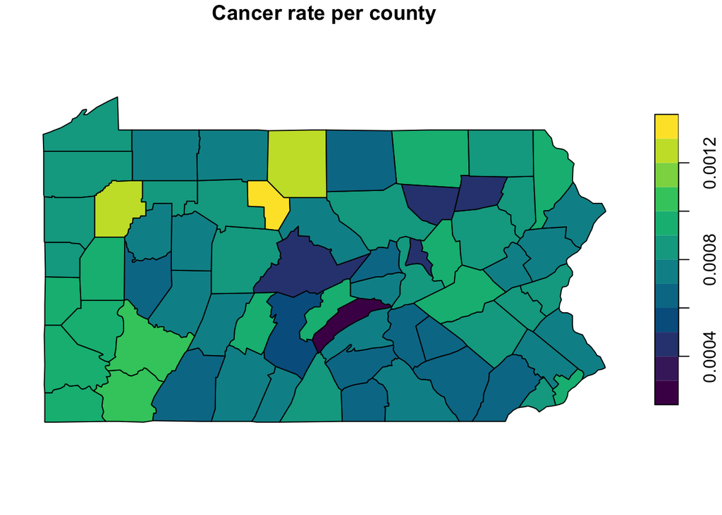

```r
cancer_rate <- penn_sfdf[, c("rate", "geometry")]
plot(cancer_rate, pal=hcl.colors, main="Cancer rate per county")
```

## (b)

Create a choropleth map of `smoking`.

**Solution**

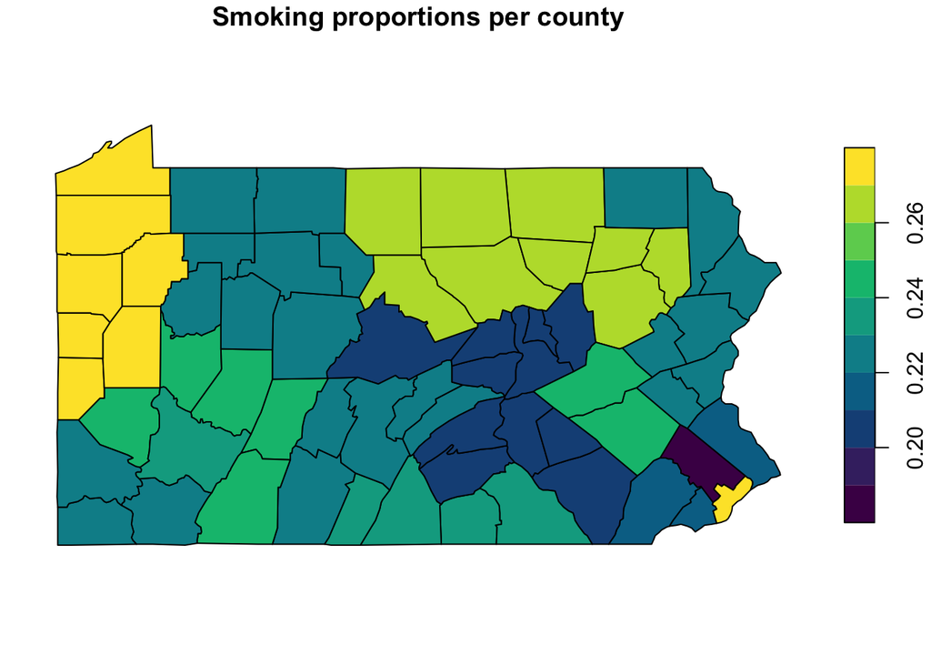

```r
smoking_prop <- penn_sfdf[, c("smoking", "geometry")]
plot(smoking_prop, pal=hcl.colors, main="Smoking proportions per county")
```

## (c)

Does there appear to be evidence of clustering of lung cancer rate/smoking in the individual maps? Are there similar patterns in the two maps?

**Solution**

There appears to be less evidence of an overlap than I was expecting actually. Smoking proportions are highest in the upper west and middle north parts of the state. There’s also a high proportion in a tiny little county in the south-east.

The highest cancer rates are found near those counties, but not exclusively. And many of the higher smoking proportion counties are very middle of the road for cancer rates.

## (d)

Describe what is occurring in the code below.

```r
library(spdep)
pennnb = spdep::poly2nb(penn_sfdf)
pennwb <- nb2listw(pennnb, style = "B")
pennws <- nb2listw(pennnb, style = "W")
```

**Solution**

This code is generating two different county adjacency objects.

The first is a binary object, it tracks which neighbors every county has and provides a weight of 1 for said neighbors.

The second is nearly identical but the weights are normalized such that they add up to 1 for each county. So a county with 3 neighbors would have weights of 1/3, 1/3, 1/3 for those neighbors.

This is simply a more robust version of the adjacency matrix that we made in a previous homework.

## (e)

The code below runs 8 different linear model-based Moran’s I tests for global spatial autocorrelation. The fitted linear models used include:

- no covariates (just an intercept)
- no covariates while adjusting the residual weights to be related to population size.
- the smoking covariate
- the smoking covariate while adjusting the residual weights to be related to population size.

The Moran’s I test was run for each model with both binary and row-standardized spatial weights matrices. The results are summarized in the table below.

| covariates | residual weights | spatial weights | p-value |
| --- | --- | --- | --- |
| none | equal | binary | 0.11 |
| none | `pop` | binary | 0.0004 |
| `smoking` | equal | binary | 0.26 |
| `smoking` | `pop` | binary | 0.01 |
| none | equal | row-standardized | 0.12 |
| none | `pop` | row-standardized | 0.0005 |
| `smoking` | equal | row-standardized | 0.244 |
| `smoking` | `pop` | row-standardized | 0.007 |

Does weighting the residuals affect the results? Do the covariates included affect the results? Does the spatial weights matrices used affect the results?

```r
# evaluate evidence for spatial dependence based on whether
# covariates are included and heterogeneous weights are accounted for
pennlm1 = lm(rate ~ 1, data = penn_sfdf)
pennlm2 = lm(rate ~ 1, data = penn_sfdf, weights = pop)
pennlm3 = lm(rate ~ smoking, data = penn_sfdf)
pennlm4 = lm(rate ~ smoking, data = penn_sfdf, weights = pop)

lm.morantest(pennlm1, pennwb)
```

```
    Global Moran I for regression residuals

data:
model: lm(formula = rate ~ 1, data = penn_sfdf)
weights: pennwb

Moran I statistic standard deviate = 1.2284, p-value = 0.1096
alternative hypothesis: greater
sample estimates:
Observed Moran I      Expectation         Variance
     0.073813364     -0.015151515      0.005244855
```

```r
lm.morantest(pennlm2, pennwb)
```

```
    Global Moran I for regression residuals

data:
model: lm(formula = rate ~ 1, data = penn_sfdf, weights = pop)
weights: pennwb

Moran I statistic standard deviate = 3.3737, p-value = 0.0003709
alternative hypothesis: greater
sample estimates:
Observed Moran I      Expectation         Variance
     0.233659603     -0.012654910      0.005330586
```

```r
lm.morantest(pennlm3, pennwb)
```

```
    Global Moran I for regression residuals

data:
model: lm(formula = rate ~ smoking, data = penn_sfdf)
weights: pennwb

Moran I statistic standard deviate = 0.64821, p-value = 0.2584
alternative hypothesis: greater
sample estimates:
Observed Moran I      Expectation         Variance
     0.025183339     -0.021177839      0.005115365
```

```r
lm.morantest(pennlm4, pennwb)
```

```
    Global Moran I for regression residuals

data:
model: lm(formula = rate ~ smoking, data = penn_sfdf, weights = pop)
weights: pennwb

Moran I statistic standard deviate = 2.2477, p-value = 0.0123
alternative hypothesis: greater
sample estimates:
Observed Moran I      Expectation         Variance
     0.148285223     -0.014781749      0.005263293
```

```r
lm.morantest(pennlm1, pennws)
```

```
    Global Moran I for regression residuals

data:
model: lm(formula = rate ~ 1, data = penn_sfdf)
weights: pennws

Moran I statistic standard deviate = 1.1681, p-value = 0.1214
alternative hypothesis: greater
sample estimates:
Observed Moran I      Expectation         Variance
      0.07298525      -0.01515152       0.00569310
```

```r
lm.morantest(pennlm2, pennws)
```

```
    Global Moran I for regression residuals

data:
model: lm(formula = rate ~ 1, data = penn_sfdf, weights = pop)
weights: pennws

Moran I statistic standard deviate = 3.304, p-value = 0.0004766
alternative hypothesis: greater
sample estimates:
Observed Moran I      Expectation         Variance
     0.236297100     -0.013419831      0.005712493
```

```r
lm.morantest(pennlm3, pennws)
```

```
    Global Moran I for regression residuals

data:
model: lm(formula = rate ~ smoking, data = penn_sfdf)
weights: pennws

Moran I statistic standard deviate = 0.69402, p-value = 0.2438
alternative hypothesis: greater
sample estimates:
Observed Moran I      Expectation         Variance
     0.030083778     -0.021604759      0.005546848
```

```r
lm.morantest(pennlm4, pennws)
```

```
    Global Moran I for regression residuals

data:
model: lm(formula = rate ~ smoking, data = penn_sfdf, weights = pop)
weights: pennws

Moran I statistic standard deviate = 2.483, p-value = 0.006514
alternative hypothesis: greater
sample estimates:
Observed Moran I      Expectation         Variance
     0.170750634     -0.015142888      0.005605005
```

**Solution**

1. Does weighting the residuals have an effect?
   - It has a pretty huge effect, yeah. When we look at the model with equal residual weights and compare it to the equivalent model with population scaled residual weights there is a drastic difference in p-values. The equal residual weights models all fail to reject the null whereas all of the population scaled ones do reject the null. So this difference results in entirely different conclusions.
2. Do the included covariates have an effect?
   - We definitely see an effect here. Going from no covariates to including smoking changes the resulting p-value quite a bit. As one example, from 0.11 to 0.26. All other instances of this also show an increase in the p-value to a similar degree.
3. Does the spatial weights matrix have an effect?
   - This one seems to not be having much of an impact at all. The models with equivalent setups but different spatial weights all have nearly equivalent results.

## (f)

Why is it appropriate to adjust the weights of the residuals to be related to the population size of each county? What do these weights imply about the variance associated with each county (see the Details section of the `lm` documentation).

**Solution**

Lower population county’s will have a higher variance for their rate, so having a weight for the population ensures that those lower population rate estimated don’t provide as much information as the larger population county’s.

So that kind of answers both questions. The docs for lm indicate that weights are used to indicate that different observations will have different variances which is exactly what we are talking about here.

## (g)

Why would you use a row-standardized spatial weights matrix instead of a binary spatial weights matrix?

**Solution**

The big upside of the row-standardized matrix is that the sum of the row is 1 (given that a region has a neighbor anyway). My hunch is that some maps may have regions with both a small number of neighbors and an extremely large number of them. In situations like that, transforming the values so that everything is on the same scale likely makes some models more well behaved.

## (h)

Construct one-parameter SAR models using `rate` as the response and `smoking` as a covariate scaling the residual error variances by a constant related to the inverse of the population size of each region and using a row-standardized spatial proximity matrix.

Provide a table with rows for the `Intercept` term, the `smoking` variable, and the $\rho$ parameter. The columns of the table should be the estimated value, the estimated standard error of the estimated value, and the p-value (for testing whether the parameter differs parameter from zero).

**Solution**

```r
# fit one-parameter SAR model with same covariates
pennsar <- spautolm(rate ~ smoking,
                  data = penn_sfdf, listw = pennws, weights=pop)

summary(pennsar)
```

```
Call: spautolm(formula = rate ~ smoking, data = penn_sfdf, listw = pennws,
    weights = pop)

Residuals:
        Min          1Q      Median          3Q         Max
-5.5493e-04 -1.1229e-04 -3.1714e-05  5.2059e-05  5.0256e-04

Coefficients:
              Estimate Std. Error z value  Pr(>|z|)
(Intercept) 0.00039400 0.00011916  3.3066 0.0009445
smoking     0.00190459 0.00048851  3.8988 9.667e-05

Lambda: 0.33286 LR test value: 4.0587 p-value: 0.043946
Numerical Hessian standard error of lambda: 0.15616

Log likelihood: 492.6419
ML residual variance (sigma squared): 0.0021831, (sigma: 0.046723)
Number of observations: 67
Number of parameters estimated: 4
AIC: NA (not available for weighted model)
```

| Term | Estimate | Std. Error | p-value |
| --- | --- | --- | --- |
| Intercept | 0.00039 | 0.00012 | 0.0009 |
| Smoking | 0.0019 | 0.00048 | $\approx0$ |
| $\rho$ | 0.333 | 0.156 | 0.044 |

## (i)

Is there evidence of residual spatial autocorrelation for the SAR model fit in the previous problem? Why?

**Solution**

There is significant evidence of residual spatial autocorrelation at the $\alpha = 0.05$ level ($p=0.044$) according to the likelihood ratio test. Though smoking itself is a significant variable at the $\alpha=0.05$ level it does not fully explain the residual spatial autocorrelation.